# Đánh giá hệ số lây nhiễm theo thời gian thực của Sởi

Author

HCDC - OUCRU

Published

September 29, 2024

# 1 Hệ số lây nhiễm - Reproduction number

**R - Hệ số lây nhiễm (Reproduction number)**

- *Hệ số lây nhiễm* *R* là số ca **thứ phát trung bình** do **một cá thể nhiễm bệnh** có thể lây truyền cho người khác **trong suốt thời kì lây nhiễm** (Cori, Ferguson, Fraser, & Cauchemez, 2013a).

**R<sub>0</sub> - Hệ số lây nhiễm cơ bản (Basic reproduction number)**

- *Hệ số lây nhiễm cơ bản,R<sub>0</sub>*, là số ca thứ phát trung bình do một cá thể nhiễm bệnh có thể lây truyền cho người khác trong suốt thời kì lây nhiễm, trong một quần thể hoàn toàn cảm nhiễm. (Vegvari et al., 2022)
- Nếu *R<sub>0</sub>* **> 1**, tác nhân gây bệnh có thể phát triển thành dịch. Nếu *R<sub>0</sub>* **< 1**, tác nhân có mức độ lây nhiễm thấp, khó có thể lây nhiễm rộng trong quần thể để gây dịch.

**R<sub>t</sub> - Hệ số lây nhiễm hiệu quả tại thời điểm (Effective reproduction number at time)**

- *Hệ số lây nhiễm hiệu quả tại thời điểm, R<sub>t</sub>* là số ca thứ phát trung bình do một cá thể nhiễm bệnh có thể lây truyền cho người khác trong suốt thời kì lây nhiễm, tại **một thời điểm nhất định**, khi quần thể **không hoàn toàn cảm nhiễm**. (“Practical considerations for measuring the effective reproductive number, rt | PLOS computational biology,” n.d.)
- *R<sub>t</sub>* thể hiện mức độ lây nhiễm trong cộng đồng theo **thời gian thực** và giúp quan sát tình hình dịch bệnh có chiều hướng tăng, giảm, hoặc ổn định. Đồng thời, có thể dựa vào chỉ số này để đánh giá **hiệu quả** của các biện pháp kiểm soát đã được thực hiện. Nếu *R<sub>t</sub> duy trì > 1* thì số ca có thể tăng, dịch bệnh có thể bùng phát trở lại; nếu *R<sub>t</sub> duy trì < 1* thì số ca có thể giảm, dịch bệnh đang được kiểm soát.
- Ước lượng *R<sub>t</sub>* rất nhạy với phân phối thời gian thế hệ (generation interval).
- Khi ước tính *R<sub>t,</sub>* cần phải xác định **khoảng tin cậy (credible interval)** để bao hàm các giá trị khả thi của *R<sub>t</sub>*.
- **R<sub>t</sub> có thể ước lượng theo 2 phương pháp:** **R<sup>*i*</sup><sub>*t*</sub>** (instantaneous reproduction number) và *R<sup>c</sup><sub>t</sub>* (case reproduction number). Xem tài liệu sau để hiểu rõ hơn về 2 chỉ số này: https://drthinhong.com/idm4b/rt.html. Hiểu một cách đơn giản là *R<sup>i</sup><sub>t</sub>* được ước tính theo thời gian thực và sử dụng dữ liệu trước thời điểm *t*, còn *R<sup>c</sup><sub>t</sub>* ước tính hồi cứu để đánh giá dịch đã xảy ra và mức độ hiệu quả của các chính sách, biện pháp can thiệp đã thực hiện.

**Ghi chú**

Đối với các phân tích theo thời gian thực nhằm đánh giá tác động của những can thiệp y tế công cộng, các khuyến cáo đề nghị sử dụng phương pháp *R<sup>i</sup><sub>t</sub>* (instantaneous reproduction number) của Cori cùng cộng sự là phù hợp nhất (Gostic et al., 2020a).

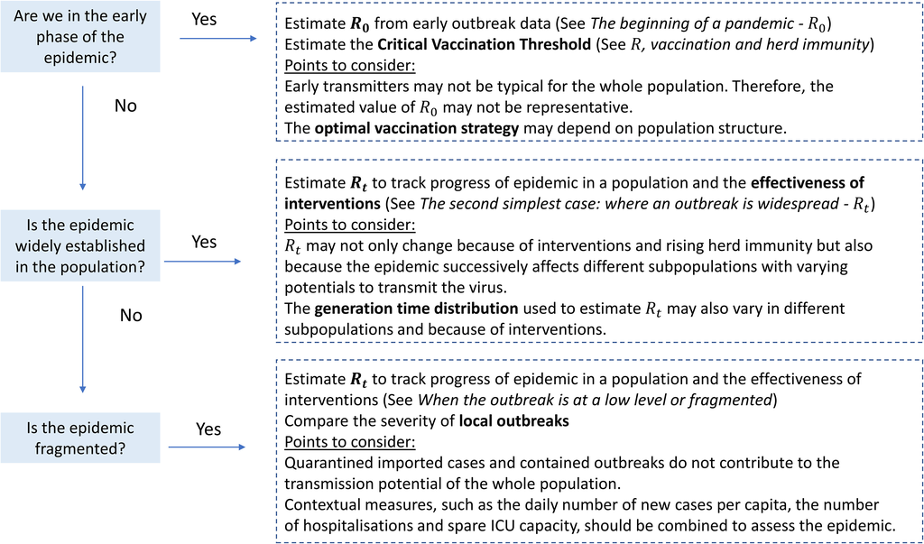

- CDC Mỹ hiện đang sử dụng R<sub>t</sub> để đánh giá mức độ lây nhiễm cho các tác nhân như COVID-19 (CDC, 2024), [đậu mùa khỉ](https://archive.cdc.gov/#/details?url=https://www.cdc.gov/poxvirus/mpox/cases-data/technical-report/technical-report-4-supplement.html)… Khuyến cáo của CDC sử dụng tỉ lệ phân phối khoảng tin cậy (KTC) của R<sub>t</sub> để phân loại tình hình dịch bệnh như sau:

**Phân độ R<sub>t</sub> (CDC, 2024)**

[figure not shown]

# 2 Thời gian thế hệ (Generation and Serial interval)

- *Khoảng thời gian thế hệ (Generation interval)*: là khoảng thời gian từ khi **ca bệnh đầu tiên bị nhiễm** đến khi lây truyền **cho các ca bệnh khác** do ca đó gây ra. (Cori, Ferguson, Fraser, & Cauchemez, 2013b).

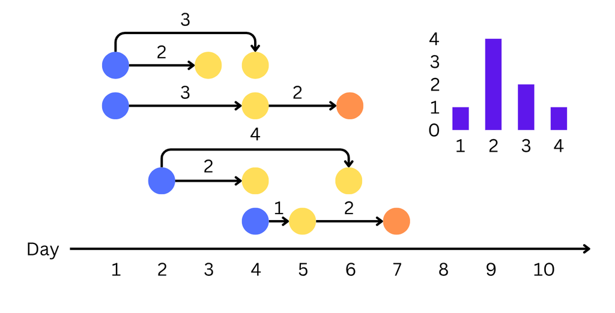

- *Khoảng thời gian nối tiếp (Serial interval)*: là khoảng thời gian từ khi một **ca bệnh khởi phát triệu chứng** đến khi các **ca bệnh do ca đó lây khởi phát triệu chứng** (Gostic et al., 2020b).

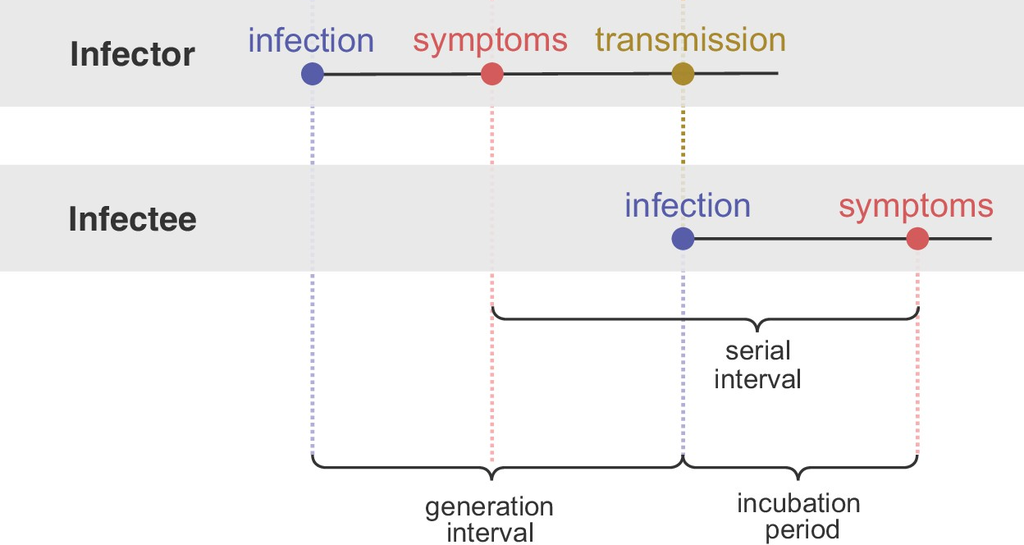

*Hình minh họa từ tác giả* (Sender et al., 2022).

# 3 Phương pháp ước tính R<sub>t</sub>

## 3.1 **Công thức:**

**Uớc tính R<sub>t</sub> theo phương pháp Cori:** (Cori, Ferguson, Fraser, & Cauchemez, 2013c)

$$R_t^i = \frac{I_t}{\sum_{s = 1}^{t} I_{t - s} w_s}$$

- **I<sub>t</sub>:** số ca nhiễm bệnh mới ghi nhận trong ngày **t**.
- **I<sub>t-s</sub>:** số người bị nhiễm bệnh **s** ngày trước đó.
- **w<sub>s</sub>:** chỉ số lây nhiễm, mô tả mức độ lây nhiễm của một cá thể kể từ **s** ngày sau khi bị nhiễm bệnh. Mức độ lây nhiễm này phụ thuộc vào khoảng thời gian từ khi cá thể bị nhiễm bệnh, nhưng không phụ thuộc vào thời điểm **t** cụ thể. Chỉ số này thường được ước lượng dựa trên khoảng thời gian thế hệ (generation interval).
- **I<sub>t-s</sub>w<sub>s</sub>:** thể hiện sự điều chỉnh số ca nhiễm **s** ngày trước bằng mức độ lây nhiễm tại thời điểm hiện tại **t** (là **s** ngày sau khi họ bị nhiễm bệnh).

## 3.2 Tiêu chuẩn để ước tính R<sub>t</sub>

**Tiêu chuẩn theo phương pháp Cori:** (Cori et al., 2013c)

- Tối thiểu sau Sliding Window size.
- Tối thiểu sau trung bình của Serival Interval.
- Tối thiểu 12 ca bệnh (ca bệnh ban đầu + 11) được quan sát kể từ khi bắt đầu dịch (trong một Sliding Window): để có được khoảng tin cậy trên là 0,3, sliding window phải bao gồm ít nhất 11 ca mắc mới.

CDC. (2024, September 20). Current epidemic growth status (based on rt) for states. Retrieved from https://www.cdc.gov/cfa-modeling-and-forecasting/rt-estimates/index.html

Cori, A., Ferguson, N. M., Fraser, C., & Cauchemez, S. (2013b). A new framework and software to estimate time-varying reproduction numbers during epidemics. *American Journal of Epidemiology*, *178*(9), 1505–1512. Retrieved from https://doi.org/10.1093/aje/kwt133

Cori, A., Ferguson, N. M., Fraser, C., & Cauchemez, S. (2013c). A new framework and software to estimate time-varying reproduction numbers during epidemics. *American Journal of Epidemiology*, *178*(9), 1505–1512. Retrieved from https://doi.org/10.1093/aje/kwt133

Cori, A., Ferguson, N. M., Fraser, C., & Cauchemez, S. (2013a). A new framework and software to estimate time-varying reproduction numbers during epidemics. *American Journal of Epidemiology*, *178*(9), 1505–1512. Retrieved from https://doi.org/10.1093/aje/kwt133

Gostic, K. M., McGough, L., Baskerville, E. B., Abbott, S., Joshi, K., Tedijanto, C., Kahn, R., et al. (2020a). Practical considerations for measuring the effective reproductive number, Rt. *PLOS Computational Biology*, *16*(12), e1008409. Retrieved from https://journals.plos.org/ploscompbiol/article?id=10.1371/journal.pcbi.1008409

Gostic, K. M., McGough, L., Baskerville, E. B., Abbott, S., Joshi, K., Tedijanto, C., Kahn, R., et al. (2020b). Practical considerations for measuring the effective reproductive number, Rt. *PLOS Computational Biology*, *16*(12), e1008409. Retrieved from https://journals.plos.org/ploscompbiol/article?id=10.1371/journal.pcbi.1008409

Practical considerations for measuring the effective reproductive number, rt | PLOS computational biology. (n.d.). Retrieved from https://journals.plos.org/ploscompbiol/article?id=10.1371/journal.pcbi.1008409

Sender, R., Bar-On, Y., Park, S. W., Noor, E., Dushoff, J., & Milo, R. (2022). The unmitigated profile of COVID-19 infectiousness. (K. Gostic, A. M. Walczak, & J. A. Hay, Eds.)*eLife*, *11*, e79134. Retrieved from https://doi.org/10.7554/eLife.79134

Vegvari, C., Abbott, S., Ball, F., Brooks-Pollock, E., Challen, R., Collyer, B. S., Dangerfield, C., et al. (2022). Commentary on the use of the reproduction number R during the COVID-19 pandemic. *Statistical Methods in Medical Research*, *31*(9), 1675–1685. Retrieved from https://doi.org/10.1177/09622802211037079